# American River

Sadie Gill, Mark Tompkins

July 2020

## Future Data Improvements

None planned.

## Instream Spawning and Rearing Habitat

**Data Source:** [ARWA 2017](https://s3-us-west-2.amazonaws.com/cvpiahabitat-r-package/cvpia-sit-model-inputs/ARWA-702.pdf) (pgs. 91-107) and [USFWS 1985](https://s3-us-west-2.amazonaws.com/cvpiahabitat-r-package/cvpia-sit-model-inputs/AmericanRiver1985IFIM.PDF) (pgs. 10-11)

### Spawning Data

Header Descriptions: flow_cfs = flow in cubic feet per second, FR_spawn_wua = Fall Run Chinook Spawning WUA, ST_spawn_wua = Steelhead Spawning WUA, watershed = section of stream modeled for CVPIA SDM

| flow_cfs | FR_spawn_wua | ST_spawn_wua | watershed |
| --- | --- | --- | --- |
| 0 | 0.00 | 0.00 | American River |
| 50 | 13209.35 | 11331.81 | American River |
| 100 | 25142.28 | 21600.69 | American River |
| 150 | 35890.51 | 30879.70 | American River |
| 200 | 45542.15 | 39238.99 | American River |

*…with 50 more rows.*

### Rearing Data

Header Descriptions: flow_cfs = flow in cubic feet per second, FR_fry_wua = Fall Run Chinook Fry WUA, FR_juv_wua = Fall Run Chinook Juvenile WUA, watershed = section of stream modeled for CVPIA SDM

| flow_cfs | FR_fry_wua | FR_juv_wua | watershed |
| --- | --- | --- | --- |
| 300 | 59897.00 | 112381.25 | American River |
| 500 | 54065.00 | 108736.25 | American River |
| 750 | 49959.25 | 99007.00 | American River |
| 1000 | 42334.00 | 93968.25 | American River |
| 1250 | 38006.00 | 86484.75 | American River |

*…with 6 more rows.*

### Spawning WUA

The Fall Run Chinook Salmon and Steelhead spawning habitat data from [ARWA 2017](https://s3-us-west-2.amazonaws.com/cvpiahabitat-r-package/cvpia-sit-model-inputs/ARWA-702.pdf) is located in Attachment B. Fall Run Chinook Salmon data are in Table B-4 on page 91 and Figure B-8 on page 92. Steelhead data are in Table B-9 and Figure B-26 on page 107.

The following plot shows the composite WUA in square feet per thousand feet for Fall Run Chinook Salmon and Steelhead. The WUA values combine data from all evaluation reaches. These area per length rates are multiplied by the total spawning reach length mapped by the SIT to estimate areas of habitat.

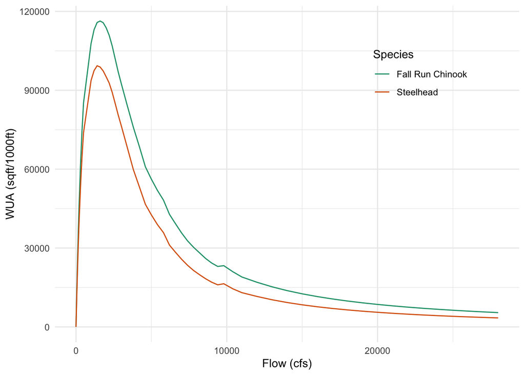

### Rearing WUA

The following plot shows the rearing WUA in square feet per thousand feet for fry and juvenile Fall Run Chinook Salmon. These rates are multiplied by the total rearing reach length mapped by the SIT to estimate habitat area.

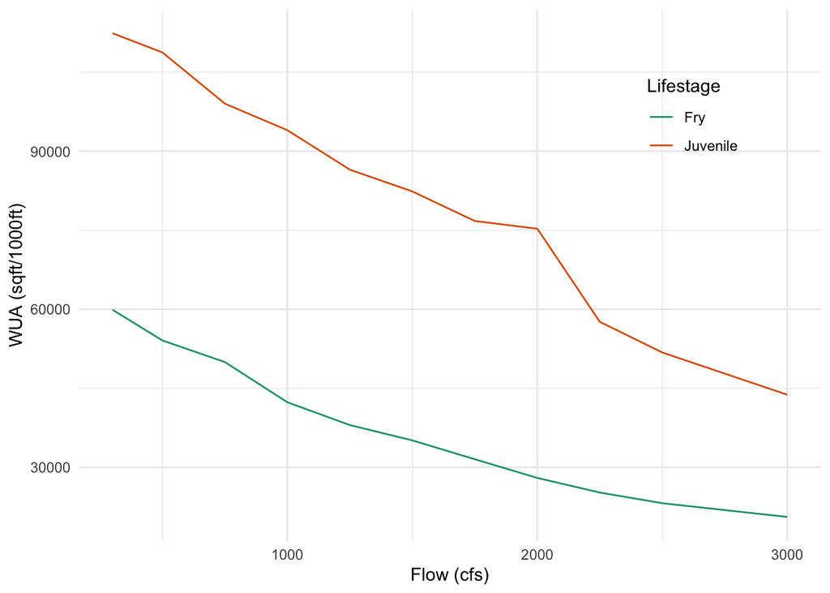

## Floodplain Rearing Habitat

**Data Source:** [Central Valley Floodplain Evaluation and Delineation (CVFED) HEC-RAS hydraulic model](https://s3-us-west-2.amazonaws.com/cvpiahabitat-r-package/cvpia-sit-model-inputs/CombinedTM_IQAR_Final-FULL-REPORT_20140206.pdf)

The entire mapped rearing extent of 22.8 miles was modeled using Central Valley Floodplain Evaluation and Delineation (CVFED) HEC-RAS hydraulic model. An active channel area of 670.2 acres, estimated through remote sensing analysis, was subtracted from total inundated area to obtain inundated floodplain area.

## Floodplain Data

The areas represent total inundated area in acres.

Header Descriptions: flow_cfs = flow in cubic feet per second, FR_floodplain_acres = Fall Run Chinook floodplain acres, ST_floodplain_acres = Steelhead floodplain acres, watershed = section of stream modeled for CVPIA SDM

| flow_cfs | FR_floodplain_acres | ST_floodplain_acres | watershed |
| --- | --- | --- | --- |
| 1200 | 0.00 | 0.00 | American River |
| 2200 | 6.00 | 6.00 | American River |
| 3200 | 159.88 | 159.88 | American River |
| 4200 | 228.01 | 228.01 | American River |
| 5200 | 268.53 | 268.53 | American River |

*…with 29 more rows*

## Floodplain Plot

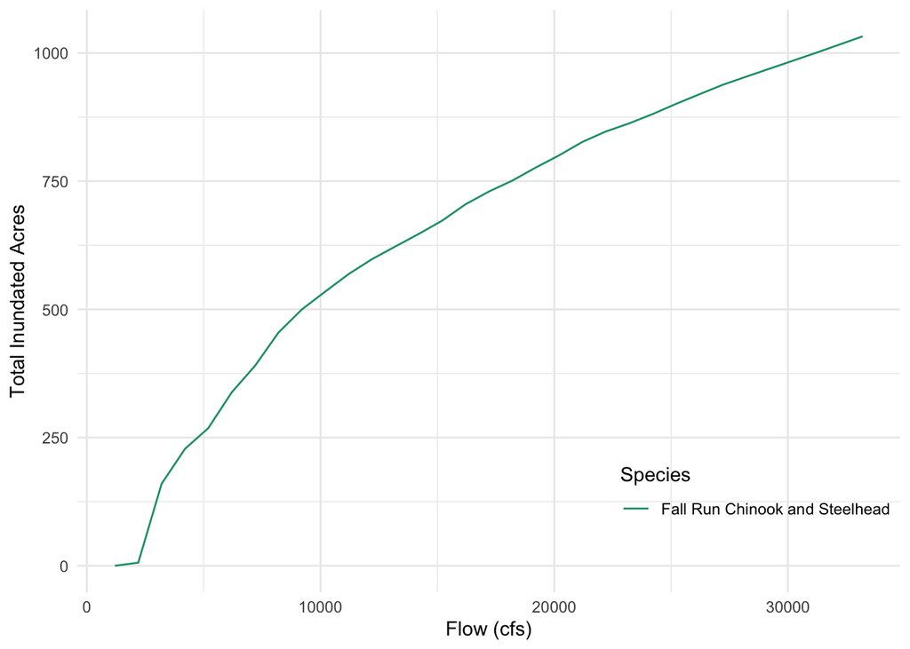